# NKI-RS VBM analysis

Kaidi Kang and Simon Vandekar

5/12/2021

# 1 Information about the data set

Nathan Kline Institute Rockland Sample (NKI-RS).

The images are voxel-based morphometry (VBM).

## 1.1 VBM images (outcome variable)

The intensity of each voxel

## 1.2 Covariates

- sex
- race
- age

## 1.3 Data setup

```r
knitr::opts_chunk$set(echo = TRUE, eval=FALSE, message=FALSE, warning=FALSE, fig.width=4.5, fig.height=4.5, cache=FALSE)
knitr::knit_hooks$set(GPs=function(before, options, envir){
  if (before){
    cex=1.5
    # graphical parameters
    fgcol = 'white'
    bgcol = 'black'
    par(mgp=c(0.9,.7,0), lwd=1.5, lend=2,
        cex.lab=cex, cex.axis=0.8*cex, cex.main=1*cex,
        mar=c(0.5,2.2,2,0), bty='l', oma=c(0,0,2,0), bg=bgcol, fg=fgcol, col.axis=fgcol, col.lab=fgcol, col.main = fgcol, col.sub=fgcol)
  }})
knitr::opts_chunk$set(echo = FALSE, fig.height = 4, fig.width = 4, GPs=TRUE, cache=FALSE, cache.lazy=FALSE, eval=FALSE)
path = Sys.getenv('PATH')
path = Sys.setenv('PATH'=paste(path, '/home/rstudio/.local/bin', sep=':'))
set.seed(555)
```

## 1.4 Setup analysis files

[output not shown]

# 2 Group level analysis

## 2.1 Model specification

This model specification is used to test the nonlinear age by sex interaction. The null hypothesis at each location is that males an females follow the same developmental trajectory.

## 2.2 Parametric test statistics

This command fits the model across the image assuming that the errors are homoskedastic, meaning that all subjects are assumed to have the same spatial covariance.

## 2.3 Robust test statistics

This model formula uses robust statistics, which does not assume the spatial covariance of the image for each subject is the same.

# 3 pbjInference

After computing the parametric or robust statistical image for the test of the nonlinear interaction, we can perform different types of inference. Here, we perform inference two ways, using local maxima and cluster extents.

We use two methods for estimating the null distribution of the test statistic. The first is the permutation procedure, which has been shown to work well in previous literature (and in our paper). The second is a Rademacher wild t bootstrap procedure that we showed in this paper to work well in small samples.

## 3.1 For parametric test statistics

margCDF will give you the unadjusted p-value  
globCDF -> adjusted p-value

## 3.2 For robust test statistics

# 4 Tables

## 4.1 Table 1. Parametric Cluster Extent Inference

| Cluster Extent | Centroid (vox) | Unadjusted p-value - boot | Unadjusted p-value - perm | FWER p-value - boot | FWER p-value - perm |
| --- | --- | --- | --- | --- | --- |
| 384 | 46, 88, 28 | 0.000 | 0.000 | 0.108 | 0.059 |
| 288 | 30, 33, 25 | 0.001 | 0.000 | 0.220 | 0.117 |
| 189 | 59, 29, 25 | 0.002 | 0.001 | 0.451 | 0.272 |
| 187 | 36, 26, 13 | 0.002 | 0.001 | 0.463 | 0.274 |
| 173 | 23, 53, 66 | 0.002 | 0.002 | 0.502 | 0.311 |
| 171 | 73, 31, 34 | 0.002 | 0.002 | 0.509 | 0.312 |
| 170 | 42, 59, 42 | 0.002 | 0.002 | 0.514 | 0.314 |
| 122 | 46, 31, 47 | 0.004 | 0.003 | 0.716 | 0.477 |
| 121 | 52, 39, 10 | 0.005 | 0.003 | 0.722 | 0.481 |
| 116 | 39, 55, 74 | 0.005 | 0.003 | 0.754 | 0.493 |

[output not shown]

## 4.2 Table 2. Robust Cluster Extent Inference

| Cluster Extent | Centroid (vox) | Unadjusted p-value - boot | Unadjusted p-value - perm | FWER p-value - boot | FWER p-value - perm |
| --- | --- | --- | --- | --- | --- |
| 405 | 45, 89, 28 | 0.000 | 0.000 | 0.048 | 0.045 |
| 210 | 29, 34, 25 | 0.001 | 0.001 | 0.214 | 0.199 |
| 155 | 41, 58, 42 | 0.002 | 0.002 | 0.354 | 0.342 |
| 139 | 52, 40, 10 | 0.002 | 0.002 | 0.397 | 0.407 |
| 134 | 73, 31, 34 | 0.002 | 0.002 | 0.417 | 0.434 |
| 115 | 36, 27, 13 | 0.003 | 0.003 | 0.508 | 0.534 |
| 110 | 59, 29, 25 | 0.003 | 0.003 | 0.541 | 0.557 |
| 101 | 71, 63, 36 | 0.004 | 0.004 | 0.596 | 0.607 |
| 100 | 23, 53, 67 | 0.004 | 0.004 | 0.602 | 0.612 |
| 96 | 47, 32, 47 | 0.004 | 0.004 | 0.621 | 0.641 |

[output not shown]

# 5 Image Display

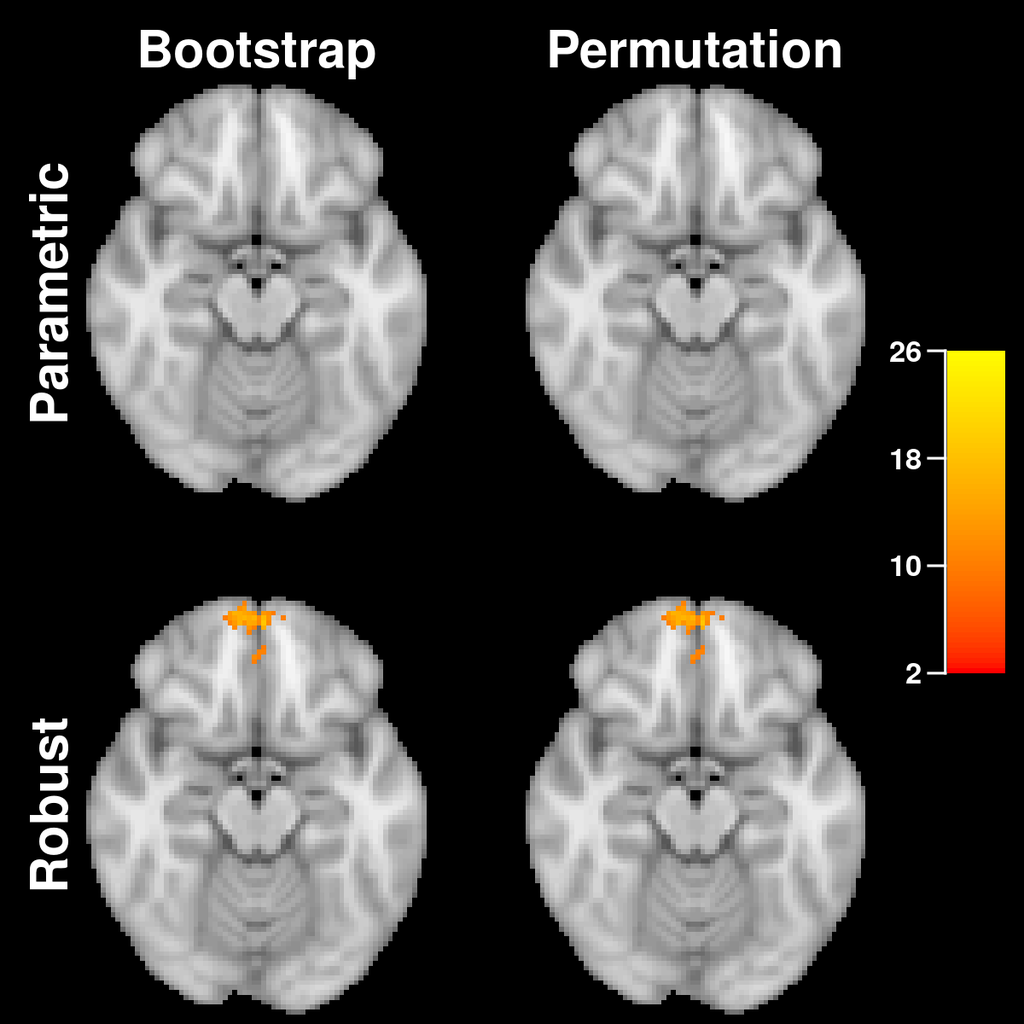

Slice 28

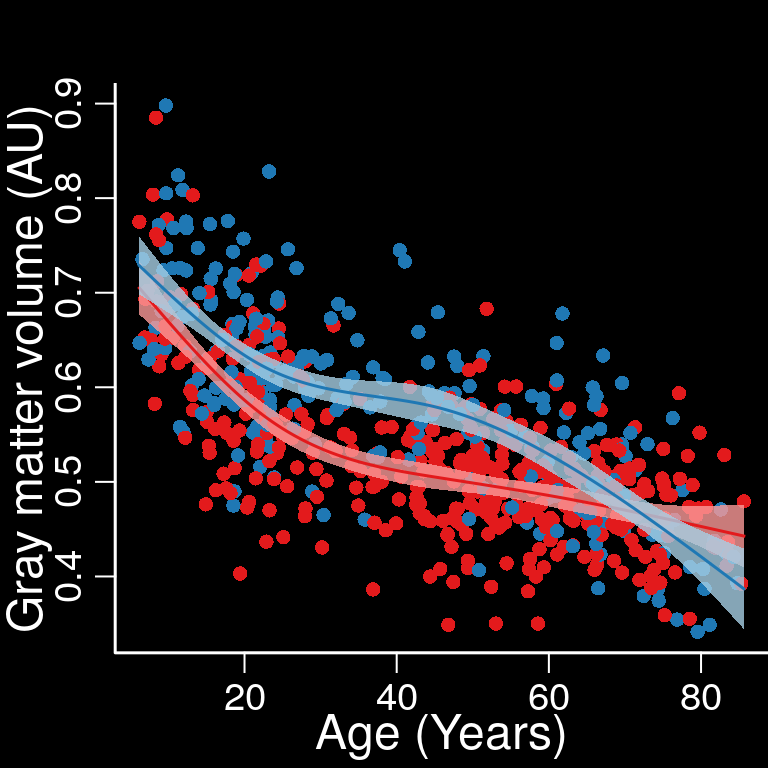

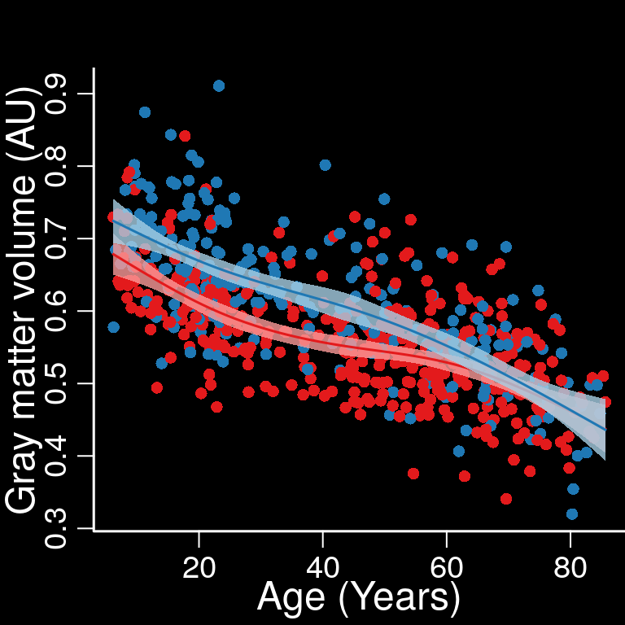

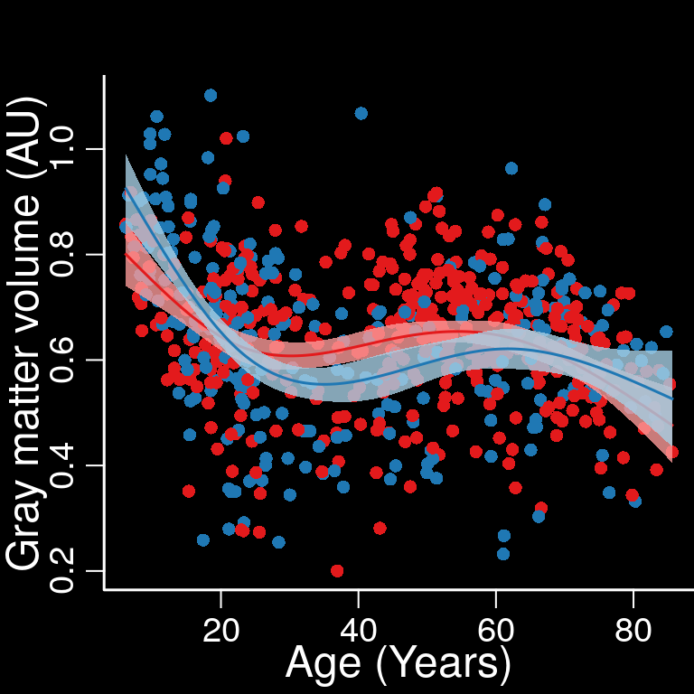

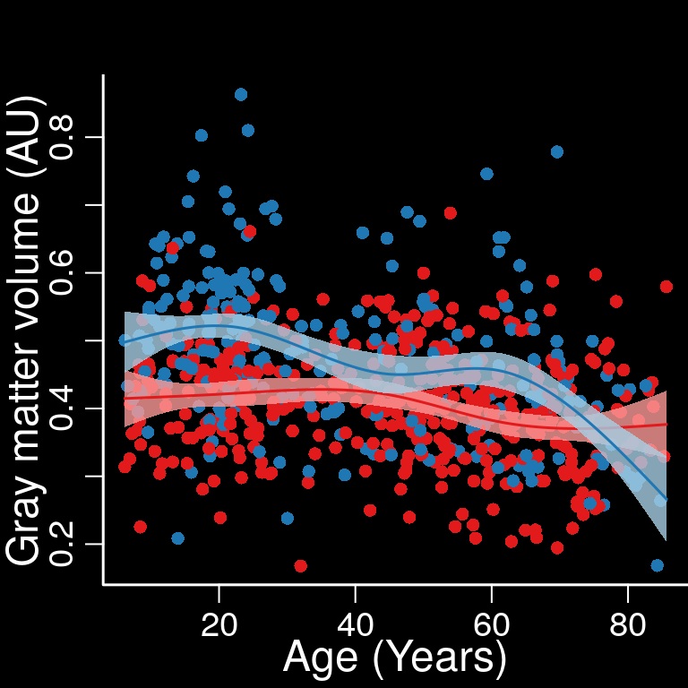

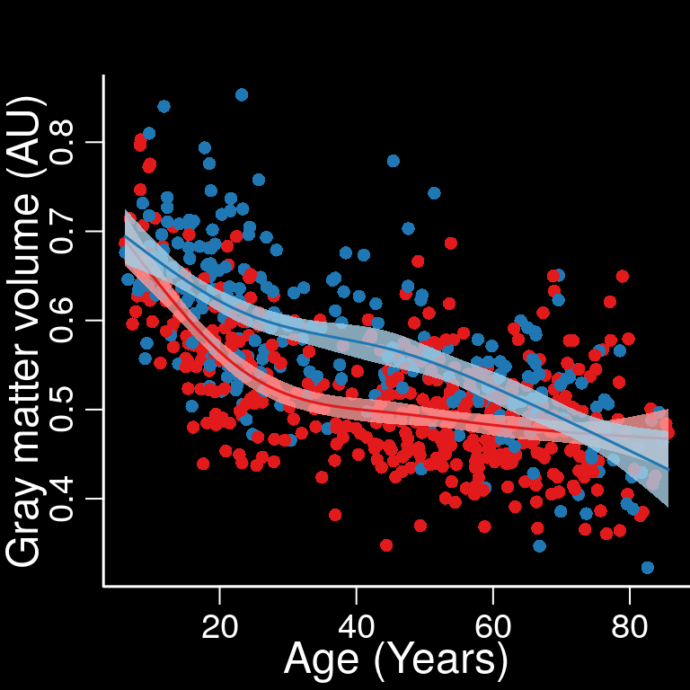